# presentation slides

Elektrauto AG  
*HWR Berlin, Sommersemester 2024*  
*Maximilian Czapons, Monika Nekipelova, Nicola Reitz*  
*27. Juni 2024*

2. Was ist der H├Âchst-, Mindest- und Durchschnittspreis?

```
(165482.31, 21471.65, 88975.19871376813)
```

1. Wie viele Autos wurden verkauft

```
1104
```

3. Wie hoch war der Gesamtumsatz?

```
98228619.38000001
```

|  | Maximaler Verkaufspreis | Minimaler Verkaufspreis | Durchschnittspreis | Gesamtumsatz |
| --- | --- | --- | --- | --- |
| 0 | 165,482.31Ôé¼ | 21,471.65Ôé¼ | 88,975.20Ôé¼ | 98,228,619.38Ôé¼ |

4. Wie viele Autos wurden pro Bundesland verkauft?

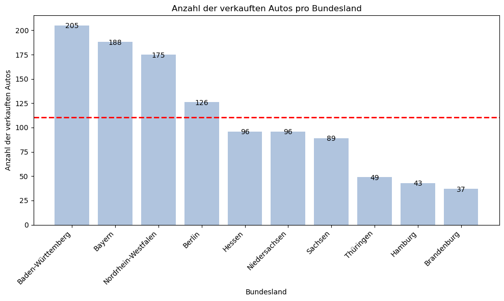

5. Wie hoch war der durchschnittliche Umsatz pro Bundesland?

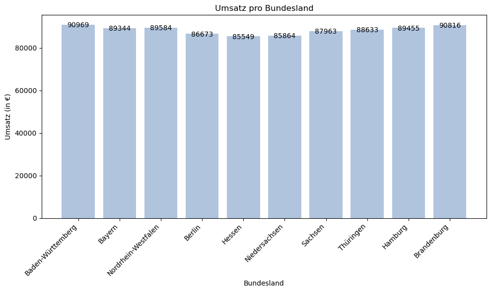

6. In welchem Bundesland wurde das teuerste Auto verkauft?

```
'Niedersachsen'
```

7. Haben mehr Frauen oder mehr M├ñnner unsere Autos gekauft?

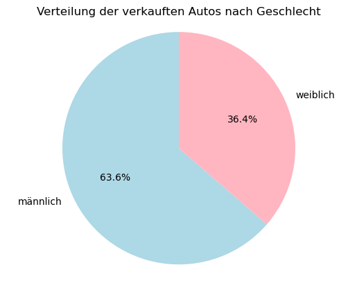

8. Wie hoch ist das Durchschnittsalter unserer Kunden? Wie hoch ist das Durchschnittsalter unserer Besucher?

```
(50.375, 49.88103254769921)
```

9. Wie hoch ist das Durchschnittseinkommen unserer Kunden? Wie hoch ist das Durchschnittseinkommen unserer Besuche

```
(58850.907608695656, 59367.93265993266)
```

10. Gibt es einen statistisch signifikanten Unterschied zwischen dem Durchschnittseinkommen der Kunden und dem der Besucher?

```
(-0.7047786382342843, 0.4810335763152168)
```

11. Pearson-Korrelations-Koeffizient zwischen den Variablen Alter, Einkommen, Preis und Zeit

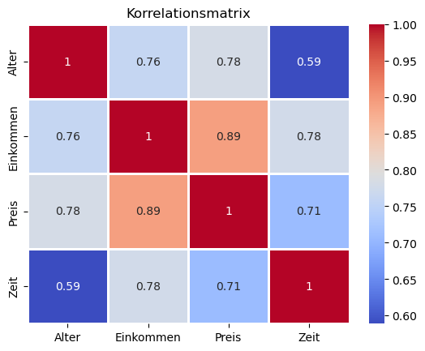

12. ist die Variable Zeit approximativ normalverteilt? (qq-Plot)>

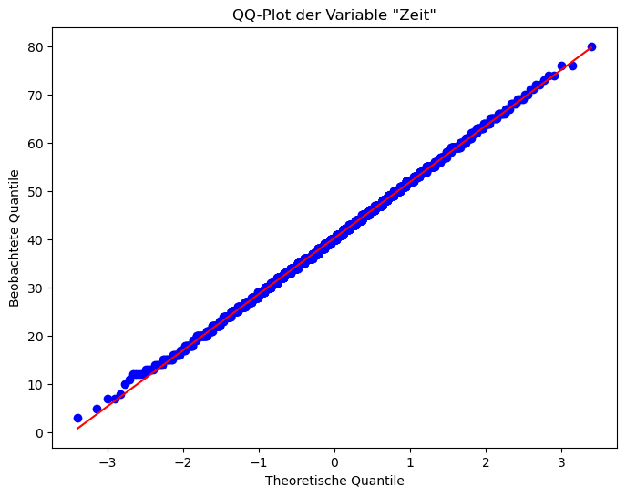

13. Wie viele Kunden haben keinen Bankkredit aufgenommen, um das Auto zu kaufen? Also wie viele Kunden haben ein Jahreseinkommen, das ├╝ber dem Autopreis liegt?

```
5
```

14. Welche sozio├Âkonomischen Merkmale beeinflussen den Kaufpreis? Sch├ñtzen Sie eine Regression.

OLS Regression Results

| Dep. Variable: | Preis | R-squared: | 0.822 |
| --- | --- | --- | --- |
| Model: | OLS | Adj. R-squared: | 0.821 |
| Method: | Least Squares | F-statistic: | 1692. |
| Date: | Wed, 26 Jun 2024 | Prob (F-statistic): | 0.00 |
| Time: | 18:26:33 | Log-Likelihood: | -11770. |
| No. Observations: | 1104 | AIC: | 2.355e+04 |
| Df Residuals: | 1100 | BIC: | 2.357e+04 |
| Df Model: | 3 |  |  |
| Covariance Type: | nonrobust |  |  |

|  | coef | std err | t | P>\|t\| | [0.025 | 0.975] |
| --- | --- | --- | --- | --- | --- | --- |
| const | 692.5659 | 1416.702 | 0.489 | 0.625 | -2087.177 | 3472.308 |
| Alter | 499.5016 | 40.136 | 12.445 | 0.000 | 420.750 | 578.253 |
| Einkommen | 1.0485 | 0.029 | 35.925 | 0.000 | 0.991 | 1.106 |
| Geschlecht | 2214.9438 | 648.591 | 3.415 | 0.001 | 942.328 | 3487.559 |

| Omnibus: | 40.847 | Durbin-Watson: | 2.104 |
| --- | --- | --- | --- |
| Prob(Omnibus): | 0.000 | Jarque-Bera (JB): | 79.427 |
| Skew: | 0.244 | Prob(JB): | 5.66e-18 |
| Kurtosis: | 4.220 | Cond. No. | 2.81e+05 |

Notes:  
[1] Standard Errors assume that the covariance matrix of the errors is correctly specified.  
[2] The condition number is large, 2.81e+05. This might indicate that there are  
strong multicollinearity or other numerical problems.

15. Prognose des Kaufpreises f├╝r 32-j├ñhrigen m├ñnnlichen Kunden mit Einkommen von 30 000 Euro. Prognose des Kaufpreises f├╝r einen m├ñnnlichen Kunden von 51 Jahren und Einkommen von 54 000 Euro.

```
0    50345.858611
1    84999.827319
dtype: float64
```

```
Intercept    -0.000000
Alter         0.244021
Einkommen     0.704733
Geschlecht    0.043492
dtype: float64
```

17. Regression, die die Wahrscheinlichkeit des Kaufs eines Autos ermittelt

|  | Alter | Einkommen | Preis | Geschlecht | Zeit | KundeNr | Niederlassung | Kauf |
| --- | --- | --- | --- | --- | --- | --- | --- | --- |
| 0 | 64 | 66894.0 | 88160.31 | 1 | 43.0 | K0310 | Bayern | 1 |
| 1 | 54 | 77644.0 | 103145.70 | 1 | 40.0 | K1042 | Berlin | 1 |
| 2 | 55 | 44341.0 | 80565.16 | 0 | 37.0 | K0382 | Baden-W├╝rttemberg | 1 |
| 3 | 49 | 67271.0 | 83949.89 | 0 | 42.0 | K0498 | Bayern | 1 |
| 4 | 46 | 49832.0 | 93781.58 | 0 | 41.0 | K0552 | Hessen | 1 |
| ... | ... | ... | ... | ... | ... | ... | ... | ... |
| 886 | 32 | 34392.0 | NaN | 1 | 48.0 | K1211 | Hessen | 0 |
| 887 | 41 | 68516.0 | NaN | 0 | 34.0 | K1375 | Sachsen | 0 |
| 888 | 65 | 89685.0 | NaN | 0 | 23.0 | K1965 | Bayern | 0 |
| 889 | 68 | 95714.0 | NaN | 0 | 32.0 | K1540 | Bayern | 0 |
| 890 | 49 | 73319.0 | NaN | 0 | 27.0 | K1207 | Niedersachsen | 0 |

1995 rows ├ù 8 columns

```
Optimization terminated successfully.
         Current function value: 0.578825
         Iterations 6
                           Logit Regression Results
==============================================================================
Dep. Variable:                   Kauf   No. Observations:                 1995
Model:                          Logit   Df Residuals:                     1990
Method:                           MLE   Df Model:                            4
Date:                Wed, 26 Jun 2024   Pseudo R-squ.:                  0.1580
Time:                        18:26:33   Log-Likelihood:                -1154.8
converged:                       True   LL-Null:                       -1371.4
Covariance Type:            nonrobust   LLR p-value:                 1.715e-92
==============================================================================
                 coef    std err          z      P>|z|      [0.025      0.975]
------------------------------------------------------------------------------
const         -2.4360      0.264     -9.242      0.000      -2.953      -1.919
Alter          0.0183      0.007      2.662      0.008       0.005       0.032
Einkommen  -4.243e-05   5.44e-06     -7.801      0.000   -5.31e-05   -3.18e-05
Geschlecht     0.2455      0.103      2.383      0.017       0.044       0.447
Zeit           0.1022      0.006     17.535      0.000       0.091       0.114
==============================================================================
```

18. Wie hoch ist die Wahrscheinlichkeit, dass Person x,y unser Auto kauft?

```
0.5465430448696972
0.7404466545605655
```

20. Vorschlaege f├╝r die Kundenabteilung

- Einheitliche Daten: entweder Trennung durch Komma oder Punkt
- Vorgegebene Antwortmoeglichkeiten, um fehlende und fehlerhafte Angaben zu vermeiden
- Geo-Daten nach genauen Standorten zum Abgleich mit lokalem Einkommensniveau und lokalen Pr├ñferenzen (Stadt, Land)
- Weitere Informationen zu Kundenpr├ñferenzen bez├╝glich Getriebe, Modell, Jahr, Kilometerstand (bei Gebrauchtwagen)
- Messung der Kundenzufriedenheit anhand einer Skala